# Feather River - Mini Snorkel Data Modeling and Analysis for Steelhead

Maddee Wiggins (FlowWest)

2026-03-12

## Objective

Develop a model that reflects the significance of cover, substrate, depth, and velocity on steelhead presence and absence.

## Analysis Overview

Model was developed using [Feather River Mini Snorkel Data](https://github.com/Healthy-Rivers-and-Landscapes-Science/feather-river/tree/main/edi-mini-snorkel) filtered to steelhead observations. The dataset consists of numeric fish count measurements that can also be represented as a binary presence–absence response. Because steelhead counts were highly zero‐inflated, with many transects recording no fish and a small number of observations containing relatively large counts, we initially explored abundance‐based modeling approaches (ie., Hurdle models). However, preliminary analyses indicated that models attempting to predict steelhead counts performed very poorly, reflecting the high variability and limited information content in the abundance data. As a result, abundance modeling was not pursued further and is not included in this document.

Subsequent analyses therefore focused on modeling steelhead occurrence using logistic regression, which better matched the structure and signal contained in the data. Mini Snorkel surveys were conducted between March and August, a period that spans substantial seasonal changes in habitat conditions and steelhead outmigration, resulting in strong temporal variation in presence. Steelhead were observed predominantly in low-flow channels, reflecting differences in habitat availability, hydraulic conditions, and refuge opportunities between channel types. Although initial exploratory analyses considered fitting separate models for high-flow and low-flow channels, we ultimately adopted a unified logistic regression framework that incorporated spatial and temporal heterogeneity through random effects. This approach allowed us to account for systematic differences among sites and seasons while retaining a single, interpretable model structure for inference.

To account for spatial and temporal structure, we evaluated a series of mixed‐effects logistic regression models that included random intercepts for transect site and month. These random effects captured persistent differences among sites, repeated sampling within transects, and seasonal shifts in steelhead presence. Among the candidate models, the best‐performing model included random effects for both site and month, highlighting the importance of spatial heterogeneity and seasonal dynamics in shaping steelhead occurrence. Including channel type as an additional random effect did not improve model performance. This final model provided the strongest overall fit and formed the basis for inference on habitat associations with steelhead presence.

## Review Data

```
## Rows: 17,396
## Columns: 44
## $ micro_hab_data_tbl_id                       <dbl> 18, 19, 20, 21, 22, 23, 24…
## $ location_table_id                           <dbl> 11, 11, 11, 11, 11, 11, 11…
## $ transect_code                               <dbl> 0.1, 0.2, 0.3, 0.4, 3.1, 3…
## $ fish_data_id                                <dbl> 23, NA, NA, NA, 25, NA, NA…
## $ date                                        <date> 2001-03-14, 2001-03-14, 2…
## $ count                                       <dbl> 1, 0, 0, 0, 3, 0, 0, 20, 1…
## $ species                                     <chr> "steelhead trout (wild)", …
## $ fl_mm                                       <dbl> 25, NA, NA, NA, 25, NA, NA…
## $ dist_to_bottom                              <dbl> 1.5, NA, NA, NA, 1.0, NA, …
## $ depth                                       <dbl> 17, 19, 11, 12, 11, 10, 8,…
## $ focal_velocity                              <dbl> 0.16, NA, NA, NA, 0.18, NA…
## $ velocity                                    <dbl> 0.22, 0.35, 1.95, 2.14, 1.…
## $ surface_turbidity                           <dbl> 20, 30, 30, 30, 10, 10, 10…
```

[output cut: 31 more lines]

## Data Exploration

### High Flow vs. Low Flow Channel

Most of the steelhead were found in the Low Flow channel.

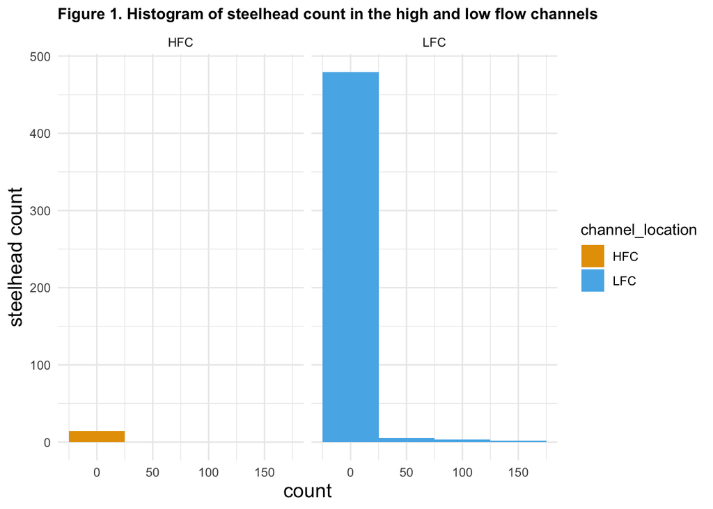

| channel_location | n |
| --- | --- |
| HFC | 50 |
| LFC | 2108 |

Table 2. Number of sampling sites in the high flow and low flow channels

| channel_location | n_sites |
| --- | --- |
| HFC | 16 |
| LFC | 13 |

### Temporal exploration

The majority of fish are found in the low flow channel with the highest counts in April.

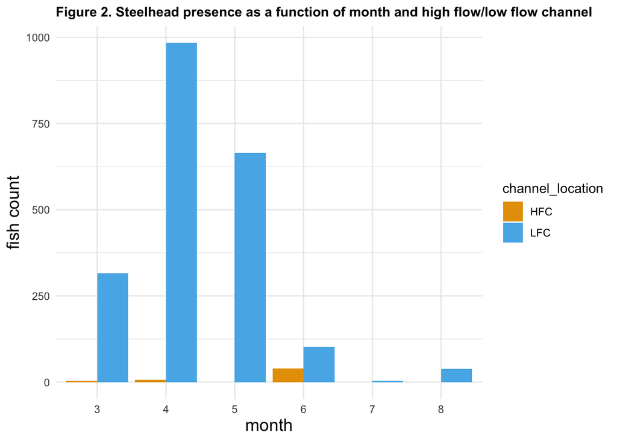

### Redd Data Integration and Exploration

**Data Question:** - for sites that include roving and transect, can I aggregate or is that double counting? Currently grouped by date and location name to get a total number of redds.

**Redd data over time**

This visual represents the number of redds over time at each location. It helps provide context on which sites generally have redds and if they have redds consistently over time.

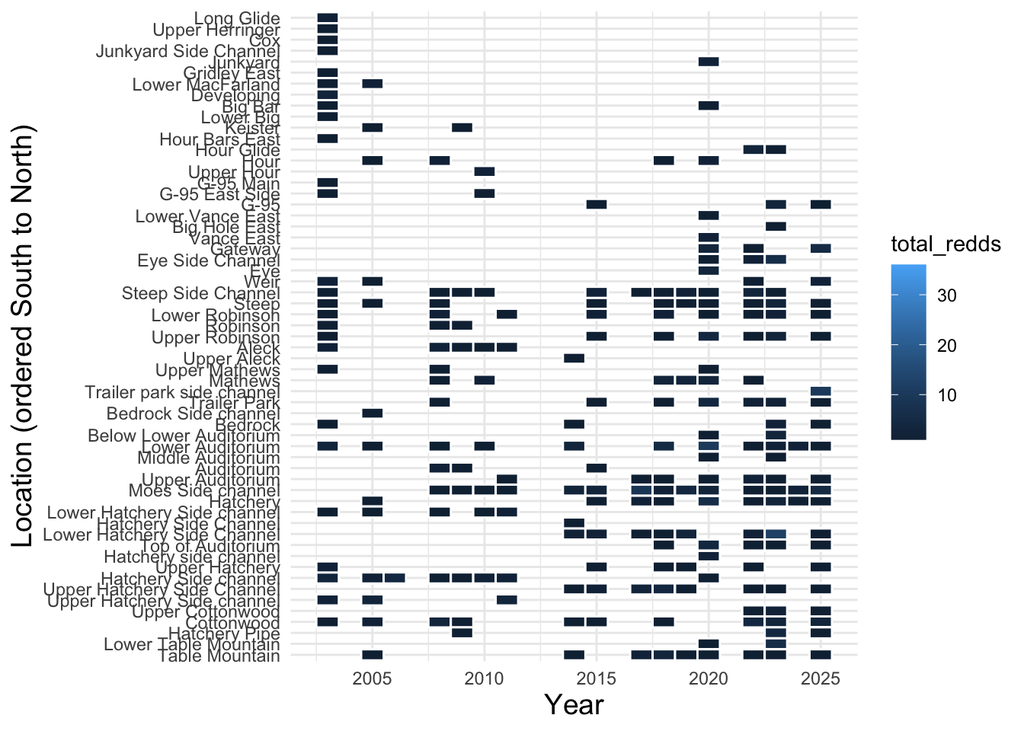

Total number of redds by year

| year | total_redds |
| --- | --- |
| 2003 | 74 |
| 2005 | 35 |
| 2006 | 4 |
| 2008 | 45 |
| 2009 | 21 |
| 2010 | 17 |
| 2011 | 26 |
| 2014 | 25 |
| 2015 | 39 |
| 2017 | 28 |
| 2018 | 142 |
| 2019 | 71 |
| 2020 | 515 |
| 2022 | 232 |
| 2023 | 212 |
| 2024 | 5 |
| 2025 | 215 |

Combine redd data with mini snorkel to see if redds are a spatial indicator or spawning potential/habitat quality.

Find the nearest transect location from the Mini Snorkel data to each redd

Redds are joined to the nearest mini snorkel transect location within 50-meters. The following histogram shows the distribution of the redd distances; 50-meters was chosen based off of the high counts (shown as the red dashed line). Note that three outliers were removed, shown in the table below. The locations (which are visible as light blue circles in the leaflet map) look to be errors.

Outliers - The following three data points seem to have incorrect coordinates

| date | location | number_redds |
| --- | --- | --- |
| 2003-01-16 | Hour Bars East | 1 |
| 2009-02-25 | Hatchery Side channel | 1 |
| 2020-02-19 | Hour | 1 |

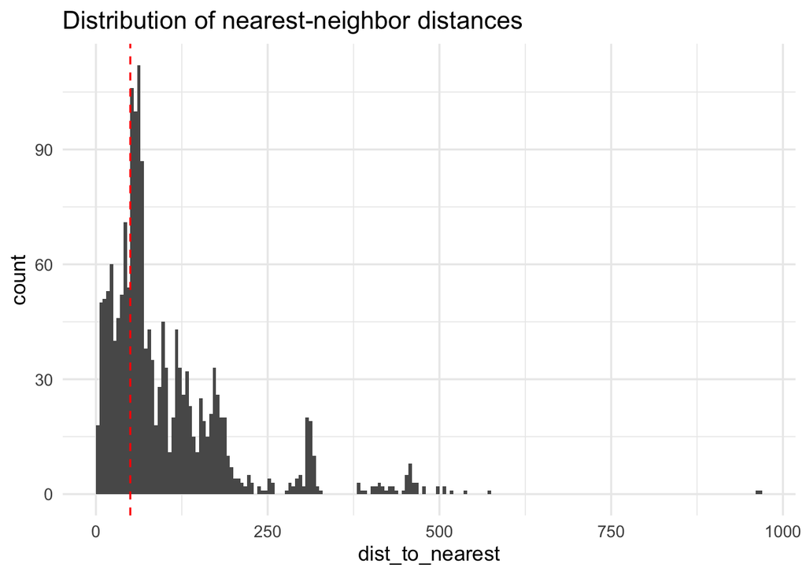

A visual representation of the amount of redds joined with each of the mini snorkel transect locations. Outliers that have been removed are shown in blue.

[interactive chart not shown]

### Variables of Interest

The variables of interest include cover, substrate, velocity and depth variables known to be important for steelhead rearing habitat. We are also including the number of redds found near each mini snorkel transect and whether or not there were redds nearby.

- Velocity - numeric
- Depth - numeric
- Number of Redds - numeric
- Redd at location - 0/1
- Month - categorical (3-8)

Substrate and cover variables are measured as percentages are converted to binary presence/absence (1/0) by establishing a threshold percentage of 20%. Overhanging vegetation was measured at 1/2 meter overhead and more than 1/2 meter overhead. These categories were combined for simplicity and for comparison with other studies, such as those by Mark Gard.

- Undercut bank - 0/1
- Aquatic vegetation - 0/1
- Overhanging vegetation - 0/1
- Small woody cover - 0/1
- Large woody cover - 0/1
- Boulder substrate - 0/1
- Cobble substrate - 0/1

## Build Model Data

All cover variables were converted to presence/absence using a threshold of 20%. The following is the data structure of the model input data.

```
## Rows: 7,949
## Columns: 30
## $ count                                       <dbl> 1, 0, 0, 0, 3, 0, 0, 20, 1…
## $ location                                    <chr> "hatchery ditch", "hatcher…
## $ channel_location                            <chr> "LFC", "LFC", "LFC", "LFC"…
## $ depth                                       <dbl> 17, 19, 11, 12, 11, 10, 8,…
## $ velocity                                    <dbl> 0.22, 0.35, 1.95, 2.14, 1.…
## $ percent_small_woody_cover_inchannel         <dbl> 15, 0, 0, 0, 20, 0, 0, 10,…
## $ percent_large_woody_cover_inchannel         <dbl> 0, 0, 0, 0, 40, 0, 0, 0, 0…
## $ percent_submerged_aquatic_veg_inchannel     <dbl> 10, 0, 0, 0, 30, 0, 0, 40,…
## $ percent_cover_half_meter_overhead           <dbl> 0, 0, 0, 0, 0, 0, 0, 25, 0…
## $ percent_cover_more_than_half_meter_overhead <dbl> 0, 0, 0, 0, 0, 0, 0, 0, 0,…
## $ percent_cobble_substrate                    <dbl> 10, 0, 0, 0, 0, 0, 0, 0, 0…
## $ percent_boulder_substrate                   <dbl> 0, 0, 0, 0, 0, 0, 0, 0, 0,…
## $ percent_undercut_bank                       <dbl> 0, 0, 0, 0, 0, 0, 0, 0, 0,…
```

[output cut: 17 more lines]

## Model Performance Evaluation Overview

Model performance was evaluated using a combination of receiver operating characteristic (ROC) analysis and confusion matrix–based classification metrics. The area under the ROC curve (AUC) was used to assess the model’s ability to discriminate between presence and absence across all possible probability thresholds. AUC provides a threshold-independent measure of performance, where values near 0.5 indicate no discrimination and higher values indicate increasing ability to correctly rank presences above absences.

In addition, model predictions were converted to binary classifications using a fixed probability threshold, and a confusion matrix was used to summarize agreement between predicted and observed outcomes. The confusion matrix tabulates true positives, true negatives, false positives, and false negatives, allowing evaluation of classification behavior such as sensitivity to presences and specificity to absences. Because the dataset was imbalanced, with many more absences than presences, emphasis was placed on interpreting the confusion matrix in conjunction with AUC rather than relying on overall accuracy alone.

Threshold predictive probabilities into 0/1 set at `0.5`.

#### Models were evaluated by the following metrics:

- **N** Total number of observations used to evaluate the model.
- **True Positives (TP)** Cases where the model predicted **presence (1)** and fish were actually **present (1)**. *Correct detections.*
- **False Positives (FP)** Cases where the model predicted **presence (1)** but fish were actually **absent (0)**. *False alarms.*
- **True Negatives (TN)** Cases where the model predicted **absence (0)** and fish were actually **absent (0)**. *Correct non-detections.*
- **False Negatives (FN)** Cases where the model predicted **absence (0)** but fish were actually **present (1)**. *Missed detections.*
- **Accuracy** The overall proportion of correct predictions: (TP + TN) / N Note: Accuracy can appear high when absences are much more common than presences.
- **Sensitivity (Recall)** Of all true presences, the proportion correctly detected: TP / (TP + FN) Measures how well the model detects fish when they are present.
- **Specificity** Of all true absences, the proportion correctly predicted as absent: TN / (TN + FP) Measures how well the model avoids false alarms.
- **Precision (Positive Predictive Value, PPV)** Of all predicted presences, the proportion that are truly present: TP / (TP + FP) Indicates how trustworthy a “presence” prediction is.
- **Negative Predictive Value (NPV)** Of all predicted absences, the proportion that are truly absent: TN / (TN + FN) Indicates how trustworthy an “absence” prediction is.
- **Balanced Accuracy** The average of sensitivity and specificity: (Sensitivity + Specificity) / 2 More informative than overall accuracy when classes are imbalanced.
- **Prevalence** The proportion of observations where fish were present: (TP + FN) / N Represents how common fish presence is in the dataset.
- **Area Under the Curve (AUC)**AUC refers to the *Area Under the Receiver Operating Characteristic (ROC) Curve*. It measures how well a model can distinguish between presence (1) and absence (0) across all possible probability thresholds, not just one cutoff.

## Logistic Regression Approach

Because fish counts were highly zero-inflated and exhibited extreme variability among non-zero values, abundance models performed poorly. We therefore focused on modeling fish occurrence using logistic regression, which better matches the information content of the data and provides more reliable inference on habitat associations.

### Build Logistic Regression Model

A simple logistic regression to start.

```
##
## Call:
## glm(formula = presence ~ small_woody + depth + velocity + large_woody +
##     aquatic_veg + overhanging_veg + cobble_substrate + boulder_substrate +
##     undercut_bank + redd_total + redd_presence + surface_turbidity,
##     family = binomial(link = "logit"), data = log_reg_data)
##
## Coefficients:
##                     Estimate Std. Error z value             Pr(>|z|)
## (Intercept)       -5.5430778  0.2305738 -24.040 < 0.0000000000000002 ***
## small_woody        0.8294897  0.1640620   5.056     0.00000042824758 ***
## depth             -0.0049301  0.0037420  -1.318             0.187670
## velocity           0.0688708  0.1058531   0.651             0.515288
## large_woody        0.3988136  0.4939782   0.807             0.419464
## aquatic_veg        0.5555381  0.1519524   3.656             0.000256 ***
## overhanging_veg    1.0857442  0.1463864   7.417     0.00000000000012 ***
## cobble_substrate   0.5167096  0.1631169   3.168             0.001536 **
## boulder_substrate  0.5961089  0.2319613   2.570             0.010174 *
## undercut_bank      1.0221268  0.4135784   2.471             0.013458 *
## redd_total         0.0105060  0.0007924  13.259 < 0.0000000000000002 ***
## redd_presence      1.1110181  0.2220948   5.002     0.00000056606352 ***
## surface_turbidity -0.0072571  0.0062145  -1.168             0.242900
## ---
## Signif. codes:  0 '***' 0.001 '**' 0.01 '*' 0.05 '.' 0.1 ' ' 1
##
## (Dispersion parameter for binomial family taken to be 1)
##
##     Null deviance: 2410.5  on 7948  degrees of freedom
## Residual deviance: 1868.0  on 7936  degrees of freedom
## AIC: 1894
##
## Number of Fisher Scoring iterations: 7
```

```
## Area under the curve: 0.8417
```

AUC of 0.84171 means The habitat variables explain some presence–absence structure, but there is still a lot of overlap/noise in the data.

Confusion Matrix:

```
##          Observed
## Predicted    0    1
##         0 7658  252
##         1   13   26
```

### Logistic Regression with Random Effect

### Random Effect of Location

```
##  Family: binomial  ( logit )
## Formula:
## presence ~ small_woody + depth + velocity + large_woody + aquatic_veg +
##     overhanging_veg + cobble_substrate + boulder_substrate +
##     undercut_bank + redd_total + redd_presence + surface_turbidity +
##     (1 | location)
## Data: log_reg_data
##
##       AIC       BIC    logLik -2*log(L)  df.resid
##    1789.6    1887.3    -880.8    1761.6      7935
##
## Random effects:
##
## Conditional model:
##  Groups   Name        Variance Std.Dev.
##  location (Intercept) 1.346    1.16
## Number of obs: 7949, groups:  location, 29
##
## Conditional model:
##                    Estimate Std. Error z value             Pr(>|z|)
## (Intercept)       -6.883243   0.596172 -11.546 < 0.0000000000000002 ***
## small_woody        0.678424   0.166563   4.073        0.00004639807 ***
## depth             -0.006906   0.004001  -1.726              0.08432 .
## velocity           0.066314   0.111519   0.595              0.55208
## large_woody        0.471035   0.510725   0.922              0.35638
## aquatic_veg        0.713772   0.159776   4.467        0.00000792052 ***
## overhanging_veg    0.924776   0.151616   6.099        0.00000000106 ***
## cobble_substrate   0.364079   0.172217   2.114              0.03451 *
## boulder_substrate  0.290861   0.236503   1.230              0.21876
## undercut_bank      0.898720   0.426703   2.106              0.03519 *
## redd_total         0.013290   0.004996   2.660              0.00782 **
## redd_presence      2.118929   0.664247   3.190              0.00142 **
## surface_turbidity -0.016143   0.006400  -2.522              0.01165 *
## ---
## Signif. codes:  0 '***' 0.001 '**' 0.01 '*' 0.05 '.' 0.1 ' ' 1
```

```
## Area under the curve: 0.8889
```

```
##          Observed
## Predicted    0    1
##         0 7646  257
##         1   25   21
```

### Random Effect of Channel Location | Location

Nesting the transect location within the high flow/low flow channel as the random effect:

```
##  Family: binomial  ( logit )
## Formula:
## presence ~ small_woody + depth + velocity + large_woody + aquatic_veg +
##     overhanging_veg + cobble_substrate + boulder_substrate +
##     undercut_bank + redd_total + redd_presence + surface_turbidity +
##     (1 | channel_location/location)
## Data: log_reg_data
##
##       AIC       BIC    logLik -2*log(L)  df.resid
##    1783.1    1887.8    -876.6    1753.1      7934
##
## Random effects:
##
## Conditional model:
##  Groups                    Name        Variance Std.Dev.
##  location:channel_location (Intercept) 0.483    0.695
##  channel_location          (Intercept) 1.782    1.335
## Number of obs: 7949, groups:
## location:channel_location, 29; channel_location, 2
##
## Conditional model:
##                    Estimate Std. Error z value      Pr(>|z|)
## (Intercept)       -5.703076   1.061038  -5.375 0.00000007658 ***
## small_woody        0.675349   0.165990   4.069 0.00004729516 ***
## depth             -0.006477   0.003977  -1.629       0.10339
## velocity           0.047753   0.111709   0.427       0.66903
## large_woody        0.480999   0.510219   0.943       0.34582
## aquatic_veg        0.713130   0.158941   4.487 0.00000723132 ***
## overhanging_veg    0.905705   0.150893   6.002 0.00000000195 ***
## cobble_substrate   0.358240   0.171344   2.091       0.03655 *
## boulder_substrate  0.292232   0.235731   1.240       0.21509
## undercut_bank      0.881216   0.422643   2.085       0.03707 *
## redd_total         0.010187   0.003129   3.256       0.00113 **
## redd_presence      0.169916   0.675114   0.252       0.80128
## surface_turbidity -0.015660   0.006378  -2.455       0.01408 *
## ---
## Signif. codes:  0 '***' 0.001 '**' 0.01 '*' 0.05 '.' 0.1 ' ' 1
```

```
## Area under the curve: 0.8864
```

```
##          Observed
## Predicted    0    1
##         0 7648  257
##         1   23   21
```

### Random Effect of Location and Month

Using location and month as the random effect.

Based off of the data exploration with majority of steelhead in the low flow channel, it is unsurprising that location is a better predictor.

```
##  Family: binomial  ( logit )
## Formula:
## presence ~ small_woody + depth + velocity + large_woody + aquatic_veg +
##     overhanging_veg + cobble_substrate + boulder_substrate +
##     undercut_bank + redd_total + redd_presence + surface_turbidity +
##     (1 | location) + (1 | month)
## Data: log_reg_data
##
##       AIC       BIC    logLik -2*log(L)  df.resid
##    1646.2    1750.9    -808.1    1616.2      7934
##
## Random effects:
##
## Conditional model:
##  Groups   Name        Variance Std.Dev.
##  location (Intercept) 1.708    1.307
##  month    (Intercept) 2.044    1.430
## Number of obs: 7949, groups:  location, 29; month, 6
##
## Conditional model:
##                    Estimate Std. Error z value             Pr(>|z|)
## (Intercept)       -7.466899   0.881520  -8.470 < 0.0000000000000002 ***
## small_woody        0.441839   0.177898   2.484             0.013004 *
## depth             -0.005998   0.004108  -1.460             0.144286
## velocity          -0.275734   0.133662  -2.063             0.039119 *
## large_woody        0.128728   0.549903   0.234             0.814914
## aquatic_veg        0.626248   0.168865   3.709             0.000208 ***
## overhanging_veg    1.022206   0.159793   6.397       0.000000000158 ***
## cobble_substrate  -0.050441   0.185496  -0.272             0.785679
## boulder_substrate -0.012012   0.243327  -0.049             0.960629
## undercut_bank      0.535684   0.457496   1.171             0.241638
## redd_total         0.013593   0.005609   2.424             0.015368 *
## redd_presence      2.438947   0.740264   3.295             0.000985 ***
## surface_turbidity -0.005166   0.006924  -0.746             0.455646
## ---
## Signif. codes:  0 '***' 0.001 '**' 0.01 '*' 0.05 '.' 0.1 ' ' 1
```

```
## Area under the curve: 0.9126
```

```
##          Observed
## Predicted    0    1
##         0 7645  222
##         1   26   56
```

The main difference in the results in the inclusion of depth as an important predictor. The AUC is the same as the model prior (with all months).

```
## Rows: 5,689
## Columns: 31
## $ count                                       <dbl> 1, 0, 0, 0, 3, 0, 0, 20, 1…
## $ location                                    <chr> "hatchery ditch", "hatcher…
## $ channel_location                            <chr> "LFC", "LFC", "LFC", "LFC"…
## $ depth                                       <dbl> 17, 19, 11, 12, 11, 10, 8,…
## $ velocity                                    <dbl> 0.22, 0.35, 1.95, 2.14, 1.…
## $ percent_small_woody_cover_inchannel         <dbl> 15, 0, 0, 0, 20, 0, 0, 10,…
## $ percent_large_woody_cover_inchannel         <dbl> 0, 0, 0, 0, 40, 0, 0, 0, 0…
## $ percent_submerged_aquatic_veg_inchannel     <dbl> 10, 0, 0, 0, 30, 0, 0, 40,…
## $ percent_cover_half_meter_overhead           <dbl> 0, 0, 0, 0, 0, 0, 0, 25, 0…
## $ percent_cover_more_than_half_meter_overhead <dbl> 0, 0, 0, 0, 0, 0, 0, 0, 0,…
## $ percent_cobble_substrate                    <dbl> 10, 0, 0, 0, 0, 0, 0, 0, 0…
## $ percent_boulder_substrate                   <dbl> 0, 0, 0, 0, 0, 0, 0, 0, 0,…
## $ percent_undercut_bank                       <dbl> 0, 0, 0, 0, 0, 0, 0, 0, 0,…
```

[output cut: 18 more lines]

```
##  Family: binomial  ( logit )
## Formula:
## presence ~ small_woody + depth + velocity + large_woody + aquatic_veg +
##     overhanging_veg + cobble_substrate + boulder_substrate +
##     undercut_bank + redd_total + redd_presence + surface_turbidity +
##     (1 | location) + (1 | month)
## Data: log_data_month_subset
##
##       AIC       BIC    logLik -2*log(L)  df.resid
##    1419.7    1519.4    -694.8    1389.7      5674
##
## Random effects:
##
## Conditional model:
##  Groups   Name        Variance Std.Dev.
##  location (Intercept) 1.8902   1.3748
##  month    (Intercept) 0.2699   0.5195
## Number of obs: 5689, groups:  location, 26; month, 4
##
## Conditional model:
##                    Estimate Std. Error z value             Pr(>|z|)
## (Intercept)       -6.550690   0.720293  -9.094 < 0.0000000000000002 ***
## small_woody        0.412497   0.187659   2.198             0.027940 *
## depth             -0.010604   0.004591  -2.310             0.020902 *
## velocity          -0.770790   0.168878  -4.564       0.000005014769 ***
## large_woody        0.208195   0.570920   0.365             0.715361
## aquatic_veg        0.644932   0.178932   3.604             0.000313 ***
## overhanging_veg    1.060408   0.170544   6.218       0.000000000504 ***
## cobble_substrate  -0.125970   0.197145  -0.639             0.522841
## boulder_substrate -0.006862   0.256505  -0.027             0.978657
## undercut_bank      0.658676   0.497794   1.323             0.185772
## redd_total         0.014152   0.005907   2.396             0.016581 *
## redd_presence      2.507548   0.780047   3.215             0.001306 **
## surface_turbidity  0.010847   0.008318   1.304             0.192214
## ---
## Signif. codes:  0 '***' 0.001 '**' 0.01 '*' 0.05 '.' 0.1 ' ' 1
```

```
## Area under the curve: 0.9126
```

```
##          Observed
## Predicted    0    1
##         0 5405  190
##         1   24   70
```

### Model Summary Table

All models showed high overall accuracy (96–97%), largely driven by the low prevalence of fish presence (3–5%). However, simple logistic and spatial-only random effects models had very low sensitivity (6–10%), indicating that they missed most true presences despite good specificity. Adding both location and month random effects substantially improved detection (sensitivity 20–27%) while maintaining high precision and excellent discrimination (AUC ≈ 0.91). The model restricted to biologically relevant months (3–6) performed best overall, achieving the highest sensitivity and balanced accuracy while retaining strong AUC.

| Model | N | True Positives | False Positives | True Negatives | False Negatives | Accuracy | Sensitivity (Recall) | Specificity | Precision (PPV) | NPV | Balanced Accuracy | Prevalence | AUC |
| --- | --- | --- | --- | --- | --- | --- | --- | --- | --- | --- | --- | --- | --- |
| simple logistic regression | 7949 | 26 | 13 | 7658 | 252 | 0.967 | 0.094 | 0.998 | 0.667 | 0.968 | 0.546 | 0.035 | 0.842 |
| random effect of location | 7949 | 21 | 25 | 7646 | 257 | 0.965 | 0.076 | 0.997 | 0.457 | 0.967 | 0.536 | 0.035 | 0.889 |
| random effect of channel_location \| location | 7949 | 21 | 23 | 7648 | 257 | 0.965 | 0.076 | 0.997 | 0.477 | 0.967 | 0.536 | 0.035 | 0.886 |
| random effect of location and month | 7949 | 56 | 26 | 7645 | 222 | 0.969 | 0.201 | 0.997 | 0.683 | 0.972 | 0.599 | 0.035 | 0.913 |
| random effect of location and months (3-6) | 5689 | 70 | 24 | 5405 | 190 | 0.962 | 0.269 | 0.996 | 0.745 | 0.966 | 0.632 | 0.046 | 0.913 |

### Figures

The following figures are for the model using location and months 3-6 as the random effect.

The following figure represents the overall effect of month on fish presence while keeping all other months constant. Points greater than 1 represent a higher probability of fish presence and points less than 1 represent a lower probability. Wider bars represent greater uncertainty.

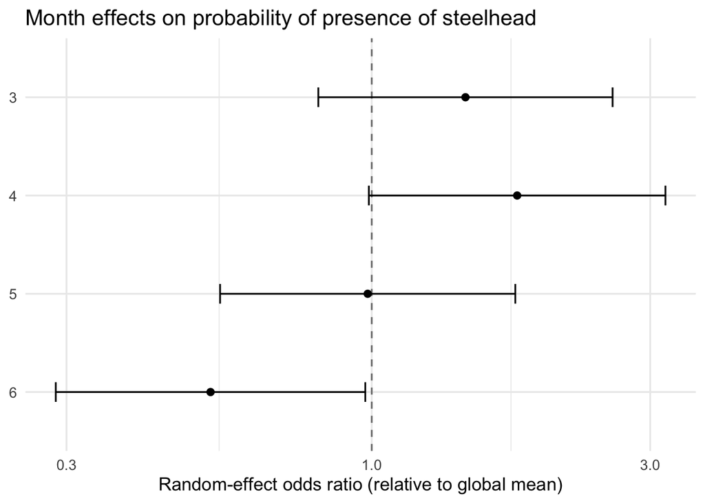

The following figure represents the overall effect of each of the sites on fish presence while keeping all other sites constant. Points greater than 1 represent a higher probability of fish presence and points less than 1 represent a lower probability. Wider bars represent greater uncertainty.

Larger impact for low flow channel.

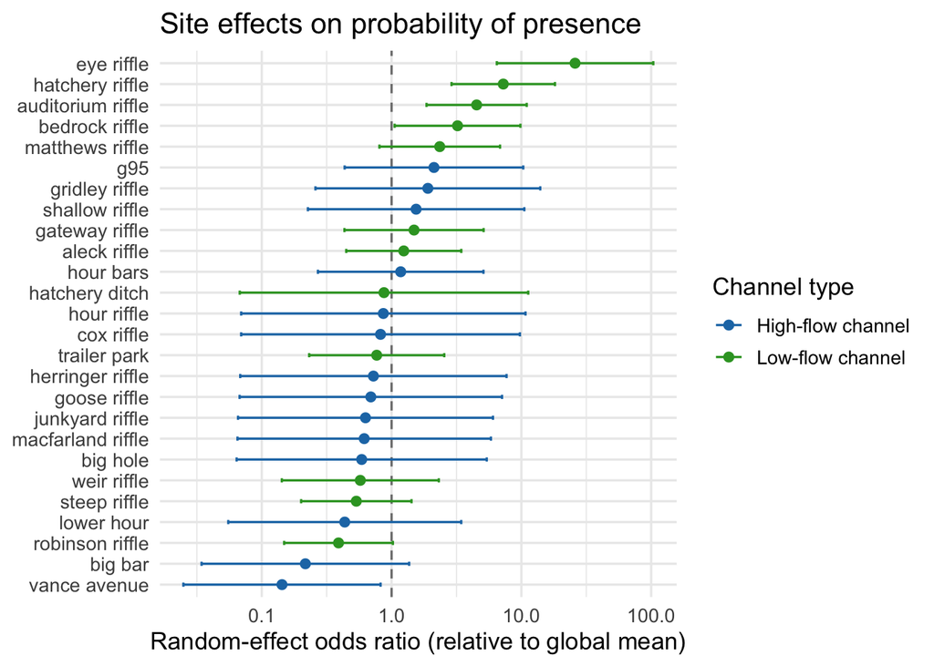

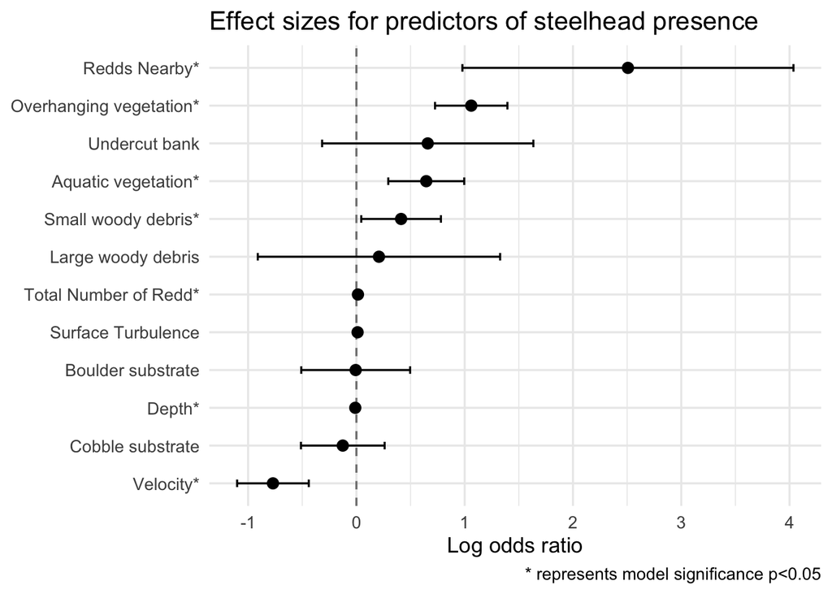

### Discussion

Structural habitat features were the most consistent predictors of steelhead presence. Overhanging vegetation, aquatic vegetation, and small woody debris were all positively associated with occurrence, indicating a strong preference for habitats that provide cover, refuge, and hydraulic complexity. These findings align with the ecology of juvenile steelhead, which typically select habitats that reduce predation risk and energetic costs. In contrast, substrate variables and large woody debris did not show strong independent effects once other habitat features were considered.

Spawning context also played a key role. The presence of nearby redds and higher total redd counts were both associated with increased probabilities of steelhead presence, suggesting spatial coupling between spawning and rearing habitats or shared reach‐scale conditions that support both life stages. While these effects were strong, they were estimated with greater uncertainty than structural habitat predictors.

### Supplementary Figures

**Conallin et al. 2014 - Figure 5**

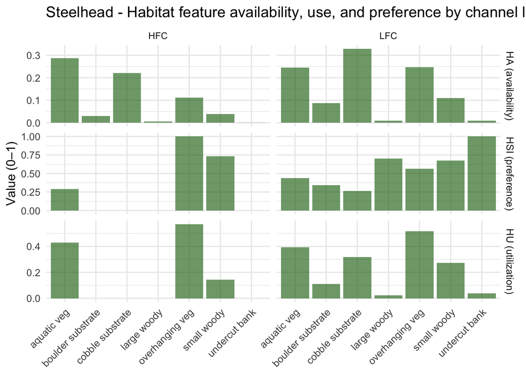